# Comparison of Filtering Strategies: Marly vs Melanie

Fay Webster

# 1 Overview

This analysis compares the output of two filtering strategies used on 16S Nanopore sequencing data for the Namibia Rodent Project:

- **Marly’s Filtering** – a standard, more stringent pipeline.
- **Melanie’s Filtering** – a lenient filtering strategy.

The goal is to determine which filtering strategy yields higher quality and more biologically meaningful taxonomic profiles for downstream integration with metadata.

We evaluate: - Read depth per sample - Read depth differences between strategies - Descriptive statistics for both pipelines

## 1.1 Setup

```r
# Load required packages
library(tidyverse)
library(janitor)
library(ggplot2)
library(vegan)

# Read annotated OTU + taxonomy + metadata tables
otu_marly <- read_csv("Data/processed/EMU_output/marly_standard_filtering/otu_taxonomy_metadata_marly.csv")
otu_melanie <- read_csv("Data/processed/EMU_output/melanie_lenient_filtering/otu_taxonomy_metadata_melanie.csv")
```

## 1.2 Read Depth Per Sample (Separate Summaries)

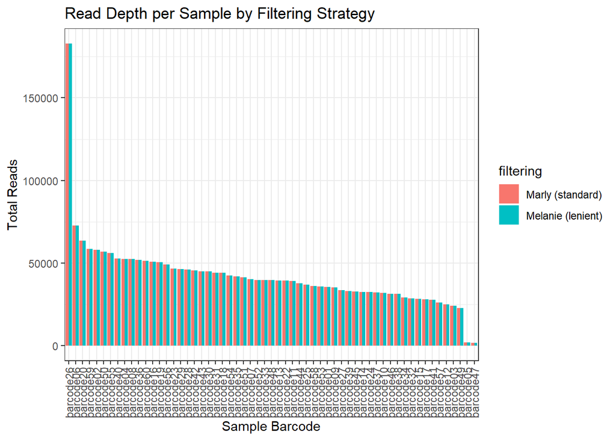

```r
# Add filtering labels
otu_marly$filtering <- "Marly (standard)"
otu_melanie$filtering <- "Melanie (lenient)"

# Summarize reads per barcode
reads_marly <- otu_marly %>%
  group_by(barcode) %>%
  summarise(total_reads = sum(count_marly, na.rm = TRUE)) %>%
  mutate(filtering = "Marly (standard)")

reads_melanie <- otu_melanie %>%
  group_by(barcode) %>%
  summarise(total_reads = sum(count_melanie, na.rm = TRUE)) %>%
  mutate(filtering = "Melanie (lenient)")

# Combine summaries
read_depth_comparison <- bind_rows(reads_marly, reads_melanie)

# Barplot: total reads per sample by filtering method
ggplot(read_depth_comparison, aes(x = reorder(barcode, -total_reads), y = total_reads, fill = filtering)) +
  geom_bar(stat = "identity", position = "dodge") +
  labs(title = "Read Depth per Sample by Filtering Strategy",
       x = "Sample Barcode", y = "Total Reads") +
  theme_bw() +
  theme(axis.text.x = element_text(angle = 90, hjust = 1, vjust = 0.5))
```

## Total Read Comparison

```r
# Total read counts
sum_marly <- sum(otu_marly$count_marly, na.rm = TRUE)
sum_melanie <- sum(otu_melanie$count_melanie, na.rm = TRUE)

# Table summary
tibble(
  Filtering = c("Marly (standard)", "Melanie (lenient)"),
  Total_Reads = c(sum_marly, sum_melanie)
)
```

```
## # A tibble: 2 × 2
##   Filtering         Total_Reads
##   <chr>                   <dbl>
## 1 Marly (standard)     2482778.
## 2 Melanie (lenient)    2482778
```

# 2 Read Depth Difference Per Sample

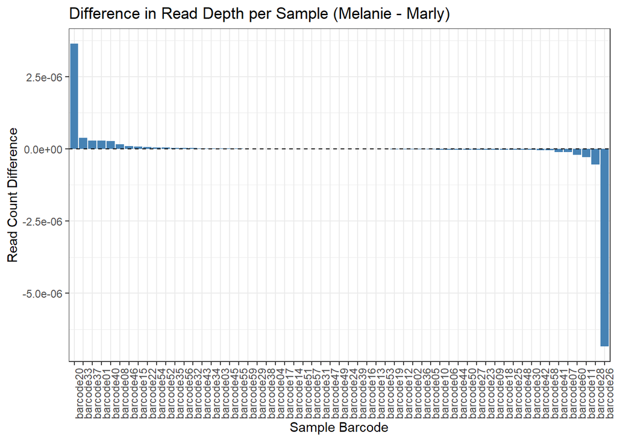

```r
# Summarize reads per sample again
reads_marly <- otu_marly %>%
  group_by(barcode) %>%
  summarise(reads_marly = sum(count_marly, na.rm = TRUE))

reads_melanie <- otu_melanie %>%
  group_by(barcode) %>%
  summarise(reads_melanie = sum(count_melanie, na.rm = TRUE))

# Join and calculate difference (Melanie - Marly)
reads_compare <- left_join(reads_marly, reads_melanie, by = "barcode") %>%
  mutate(diff = reads_melanie - reads_marly)

# Plot differences
ggplot(reads_compare, aes(x = reorder(barcode, -diff), y = diff)) +
  geom_col(fill = "steelblue") +
  geom_hline(yintercept = 0, linetype = "dashed") +
  labs(title = "Difference in Read Depth per Sample (Melanie - Marly)",
       x = "Sample Barcode", y = "Read Count Difference") +
  theme_bw() +
  theme(axis.text.x = element_text(angle = 90, hjust = 1))
```

## Summary The total read counts across both pipelines are nearly identical.

Further comparison will explore taxonomic diversity, low-abundance taxa, and ecological patterns

## 2.1 Alpha Diversity Metrics

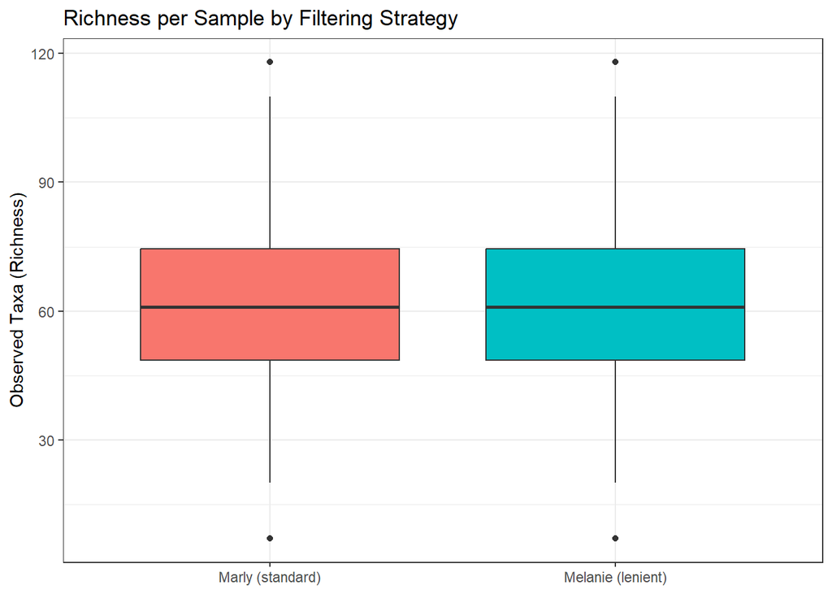

```r
# Calculate taxonomic richness and Shannon for each dataset
# Function to calculate richness and Shannon index per sample
calculate_alpha <- function(df, count_col) {
  df %>%
    filter(!is.na(!!sym(count_col))) %>%
    group_by(barcode) %>%
    summarise(
      richness = n_distinct(tax_id[!!sym(count_col) > 0]),
      shannon = diversity(!!sym(count_col), index = "shannon")
    )
}

alpha_marly <- calculate_alpha(otu_marly, "count_marly") %>%
  mutate(filtering = "Marly (standard)")
alpha_melanie <- calculate_alpha(otu_melanie, "count_melanie") %>%
  mutate(filtering = "Melanie (lenient)")

# Combine
alpha_diversity <- bind_rows(alpha_marly, alpha_melanie)

# Plot richness
ggplot(alpha_diversity, aes(x = filtering, y = richness, fill = filtering)) +
  geom_boxplot() +
  labs(title = "Richness per Sample by Filtering Strategy",
       y = "Observed Taxa (Richness)", x = NULL) +
  theme_bw() +
  theme(legend.position = "none")
```

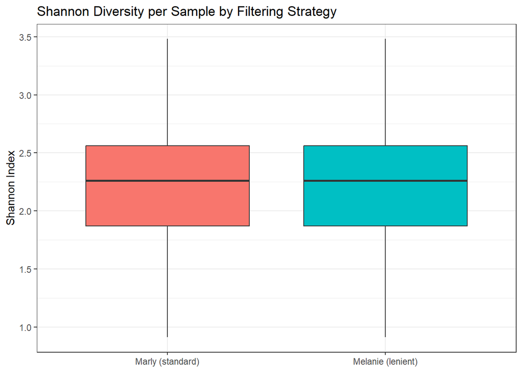

```r
# Plot Shannon
ggplot(alpha_diversity, aes(x = filtering, y = shannon, fill = filtering)) +
  geom_boxplot() +
  labs(title = "Shannon Diversity per Sample by Filtering Strategy",
       y = "Shannon Index", x = NULL) +
  theme_bw() +
  theme(legend.position = "none")
```

## 2.2 Alpha Diversity Results

### 2.2.2 Shannon Diversity per Sample

- Shannon diversity indices are highly similar across both strategies.
- Median values and interquartile ranges overlap.
- Both filtering methods preserve community evenness and overall taxonomic entropy.
- **Interpretation:** There is no evidence that one strategy over- or underestimates diversity — both appear robust for overall alpha diversity.

## 2.3 Compare OTU Richness (Unique tax IDs)

This step evaluates how many unique taxonomic IDs (OTUs) were detected by each filtering strategy. This gives insight into potential over- or under-filtering effects on microbial community resolution.

```r
# Unique tax IDs detected per filtering strategy
richness_marly <- otu_marly %>%
  filter(count_marly > 0) %>%
  distinct(tax_id) %>%
  summarise(rich_taxa = n()) %>%
  mutate(filtering = "Marly (standard)")

richness_melanie <- otu_melanie %>%
  filter(count_melanie > 0) %>%
  distinct(tax_id) %>%
  summarise(rich_taxa = n()) %>%
  mutate(filtering = "Melanie (lenient)")

# Combine results
otu_richness <- bind_rows(richness_marly, richness_melanie)

# Display table
knitr::kable(otu_richness, caption = "Unique Taxonomic IDs Detected by Filtering Strategy")
```

Unique Taxonomic IDs Detected by Filtering Strategy

| rich_taxa | filtering |
| --- | --- |
| 324 | Marly (standard) |
| 324 | Melanie (lenient) |

### 2.3.1 OTU Richness Summary

We calculated the total number of unique taxonomic identifiers (tax_id) detected by each EMU output.

The number of observed taxa was identical across both filtering strategies.

#### 2.3.1.1 Interpretation

Marly (standard) and Melanie (lenient) both recovered 324 unique OTUs.

Despite differences in filtering thresholds, both approaches converge on the same number of taxa after metadata merging and filtering.

## 2.4 Step 4: Detect & Compare Rare Taxa (Low-Abundance OTUs)

This step helps identify how many taxa are:

Singletons: detected only once across all samples

Doubletons: detected exactly twice

Low-abundance: total counts across all samples <10

```r
# Function to summarise rare taxa across all samples
summarise_rare_taxa <- function(df, count_col, label) {
  df %>%
    group_by(tax_id) %>%
    summarise(total_abundance = sum(.data[[count_col]], na.rm = TRUE)) %>%
    summarise(
      singletons = sum(total_abundance == 1),
      doubletons = sum(total_abundance == 2),
      low_abundance = sum(total_abundance < 10),
      total_taxa = n()
    ) %>%
    mutate(filtering = label)
}

rare_marly <- summarise_rare_taxa(otu_marly, "count_marly", "Marly (standard)")
rare_melanie <- summarise_rare_taxa(otu_melanie, "count_melanie", "Melanie (lenient)")

# Combine and display
rare_taxa_summary <- bind_rows(rare_marly, rare_melanie)

knitr::kable(rare_taxa_summary, caption = "Rare Taxa Statistics by Filtering Strategy")
```

Rare Taxa Statistics by Filtering Strategy

| singletons | doubletons | low_abundance | total_taxa | filtering |
| --- | --- | --- | --- | --- |
| 0 | 0 | 14 | 338 | Marly (standard) |
| 0 | 0 | 14 | 338 | Melanie (lenient) |

### 2.4.1 Rare Taxa Summary

We assessed how many OTUs fall into three categories of rarity:

Singletons: detected only once across all samples

Doubletons: detected exactly twice

Low-abundance taxa: fewer than 10 reads total across all samples

#### 2.4.1.1 Interpretation

Both pipelines perform identically in terms of removing extremely rare taxa.

- The absence of singletons and doubletons suggests that post-EMU and filtering steps effectively remove noise and potential artifacts.
- 14 taxa remained with total read counts <10 — these could be biologically rare taxa or borderline noise.
- Conclusion: No evidence that one strategy over-retains low-abundance OTUs.
- Filtering stringency appears aligned in final outputs.

## 2.5 Compare Taxonomic Composition (Phylum-Level)

Now we’ll check:

The overall composition of microbial communities

Whether different phyla dominate under each filtering strategy

We’ll use a barplot showing the relative abundance of the top phyla per strategy.

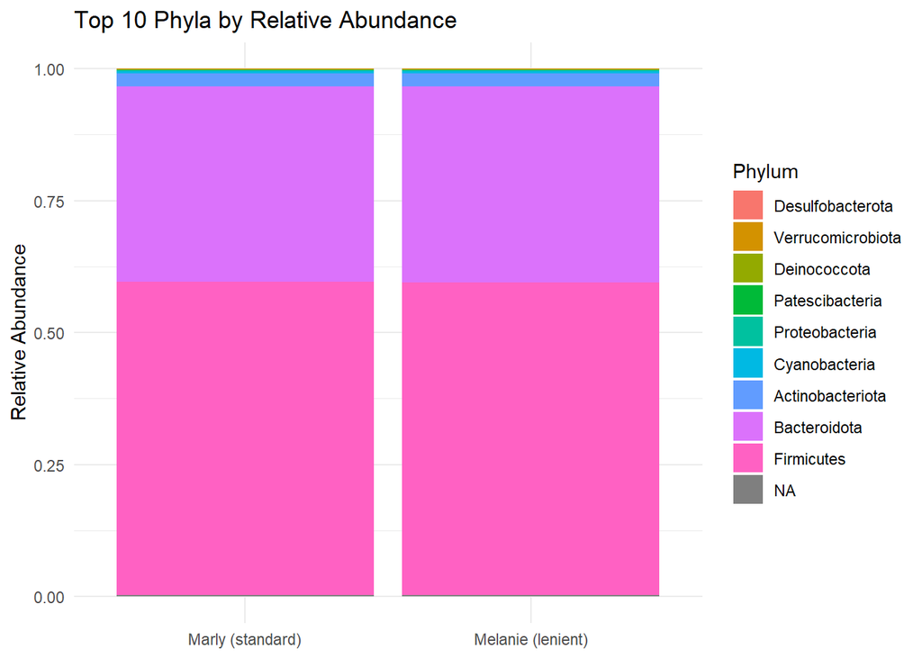

```r
# Combine both datasets with matching column names
otu_marly_long <- otu_marly %>%
  select(barcode, tax_id, count = count_marly, phylum) %>%
  mutate(filtering = "Marly (standard)")

otu_melanie_long <- otu_melanie %>%
  select(barcode, tax_id, count = count_melanie, phylum) %>%
  mutate(filtering = "Melanie (lenient)")

otu_combined_long <- bind_rows(otu_marly_long, otu_melanie_long)

# Summarise total counts by phylum and filtering strategy
top_phyla <- otu_combined_long %>%
  group_by(filtering, phylum) %>%
  summarise(total_reads = sum(count, na.rm = TRUE), .groups = "drop") %>%
  group_by(filtering) %>%
  mutate(rel_abundance = total_reads / sum(total_reads)) %>%
  arrange(desc(rel_abundance)) %>%
  group_by(filtering) %>%
  slice_max(order_by = rel_abundance, n = 10)

# Plot stacked barplot
ggplot(top_phyla, aes(x = filtering, y = rel_abundance, fill = fct_reorder(phylum, rel_abundance))) +
  geom_col(position = "stack") +
  labs(title = "Top 10 Phyla by Relative Abundance",
       x = NULL, y = "Relative Abundance", fill = "Phylum") +
  theme_minimal()
```

### 2.5.1 Phylum-Level Composition Summary

We visualized the top 10 phyla by relative abundance across both filtering strategies.

The bar plot shows stacked proportions of total read abundance per phylum, grouped by filtering approach.

#### 2.5.1.1 Interpretation

- Bacteroidota and Firmicutes dominate both datasets, comprising the majority of reads.
- Minor phyla such as Actinobacteriota, Proteobacteria, and Cyanobacteria are also consistently represented.
- No phylum was uniquely present or absent in either strategy.
- The relative proportions of major phyla are highly consistent between Marly and Melanie outputs.

#### 2.5.1.2 Conclusion:

Both pipelines preserve broad community structure and relative taxonomic profiles. Filtering differences do not shift dominant community composition at the phylum level.

## 2.6 Rarefaction Curves

Rarefaction curves visualize the relationship between sequencing depth and taxonomic richness across samples. They help assess:

Whether sequencing effort was sufficient

If one filtering strategy retains more taxa at similar depth

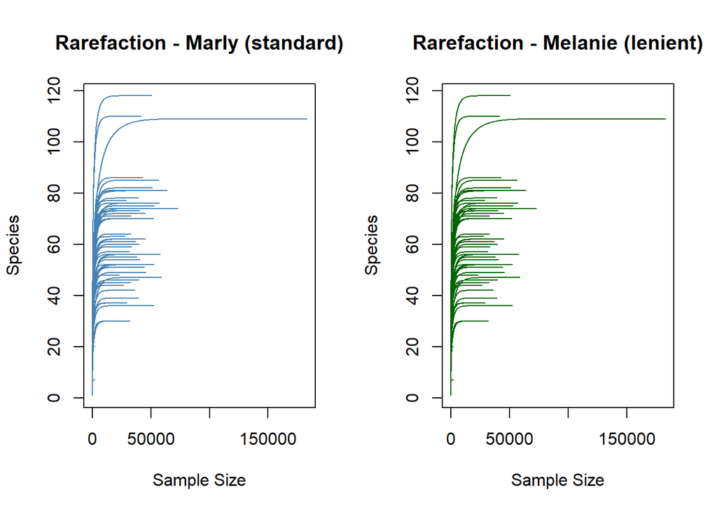

```r
# Convert wide and round to integers
# Marly abundance matrix
otu_marly_wide <- otu_marly %>%
  select(barcode, tax_id, count_marly) %>%
  pivot_wider(names_from = tax_id, values_from = count_marly) %>%
  replace(is.na(.), 0) %>%  # force replace NAs
  column_to_rownames("barcode") %>%
  as.matrix() %>%
  round()

# Melanie abundance matrix
otu_melanie_wide <- otu_melanie %>%
  select(barcode, tax_id, count_melanie) %>%
  pivot_wider(names_from = tax_id, values_from = count_melanie) %>%
  replace(is.na(.), 0) %>%
  column_to_rownames("barcode") %>%
  as.matrix() %>%
  round()

# Plot rarefaction curves
par(mfrow = c(1, 2))
rarecurve(otu_marly_wide, step = 100, label = FALSE, col = "steelblue",
          main = "Rarefaction - Marly (standard)")
rarecurve(otu_melanie_wide, step = 100, label = FALSE, col = "darkgreen",
          main = "Rarefaction - Melanie (lenient)")
```

### 2.6.1 Rarefaction Curve Summary

Rarefaction curves illustrate the relationship between sequencing depth and taxonomic richness (number of species/OTUs observed per sample).

#### 2.6.1.2 Conclusion

The rarefaction analysis confirms that both filtering strategies preserve comparable levels of within-sample taxonomic richness.

No evidence suggests under-sampling or diversity loss in either pipeline.

## 2.7 Beta Diversity & Ordination

Beta diversity helps us understand how community composition varies between samples. We’ll:

Transform the OTU tables to relative abundance

Calculate Bray-Curtis distances

Perform non-metric multidimensional scaling (NMDS)

Visualize using an ordination plot colored by filtering strategy

```r
# Prepare relative abundance matrices
ra_marly <- sweep(otu_marly_wide, 1, rowSums(otu_marly_wide), FUN = "/")
ra_melanie <- sweep(otu_melanie_wide, 1, rowSums(otu_melanie_wide), FUN = "/")

# Add sample IDs
ra_marly_df <- as.data.frame(ra_marly) %>%
  mutate(barcode = rownames(ra_marly),
         filtering = "Marly (standard)")

ra_melanie_df <- as.data.frame(ra_melanie) %>%
  mutate(barcode = rownames(ra_melanie),
         filtering = "Melanie (lenient)")

# Combine
otu_rel_abund <- bind_rows(ra_marly_df, ra_melanie_df)
otu_matrix <- otu_rel_abund %>%
  select(-barcode, -filtering) %>%
  as.matrix()

# Perform NMDS using vegan
set.seed(123)
nmds <- vegan::metaMDS(otu_matrix, distance = "bray", k = 2, trymax = 100)
```

```
## *** Best solution repeated 1 times
```

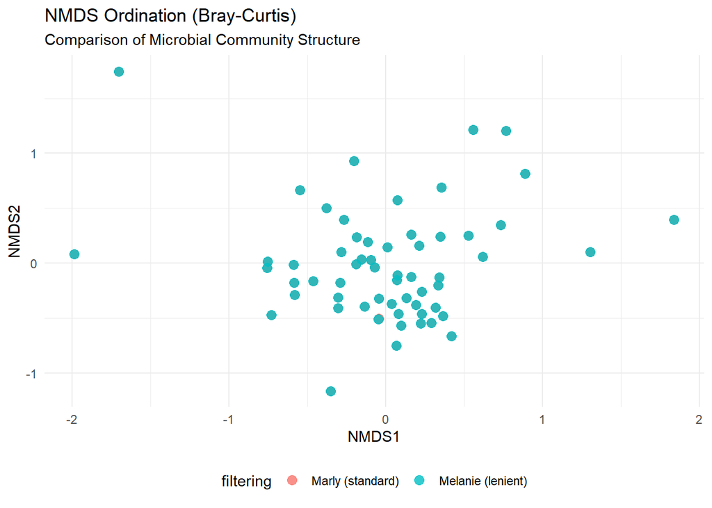

```r
# Extract NMDS coordinates
nmds_points <- as.data.frame(nmds$points) %>%
  mutate(barcode = otu_rel_abund$barcode,
         filtering = otu_rel_abund$filtering)

# Plot
ggplot(nmds_points, aes(x = MDS1, y = MDS2, color = filtering)) +
  geom_point(size = 3, alpha = 0.8) +
  labs(title = "NMDS Ordination (Bray-Curtis)",
       subtitle = "Comparison of Microbial Community Structure",
       x = "NMDS1", y = "NMDS2") +
  theme_minimal() +
  theme(legend.position = "bottom")
```

### 2.7.1 Conclusion

Both pipelines produce comparable community composition profiles.

No evidence that one filtering method substantially shifts beta diversity structure.

This supports robustness of EMU taxonomic assignments across filtering strategies.